# Introducción a

## Y, finalmente Jupyter notebooks

En la propia distribución de Anaconda viene Jupyter instalado. Jupyter no es exclusivo de python. De hecho se pensó para tres lenguajes: Julia, python y R, de ahí el nombre.

Para trabajar con Jupyter en R basta con instalar un R kernel desde un terminal:

`$>conda install -c r r-irkernel`

Desde este momento si abrimos un `jupyter notebook` podremos elegir el kernel de R.

Los notebooks tienen la ventaja de intercalar texto formateado según código HTML y MarkDown, además de imágenes y fórmulas ($\LaTeX$) con celdas de código **interactivas**.

Esto también se consigue con el formato RMarkdown (.Rmd) donde además las opciones de formateo son muchas más y más variadas. Como contrapartida en RMarkdown el código es estático, no se puede modificar, existe un paso previo para publicar un RMarkdown que es el proceso de `knitr` donde se preejecutan tanto las celdas de texto como las de código.

# R Basics

## Expresiones, Objetos y Símbolos

El código R está compuesto de expresiones (expressions). Algunos ejemplos de expresiones:

- Asignaciones
- Sentencias condicionales
- Operaciones aritméticas …

Las expresiones se componen de objetos y funciones. Cada expresión se separa de otra mediante una nueva línea o un punto y coma (;).

El código R manipula objetos (objects). Algunos ejemplos de objetos:

- Vectores
- Listas
- Funciones …

Formalmente los nombres de las variables en R se llaman símbolos (symbols). Es decir, asignamos el objeto a un símbolo del entorno actual.

El entorno está formado por el conjunto de símbolos presentes en un cierto contexto.

Los objetos en R tienen modo, clase, y tipo:

- Modo (mode): indica el modo de un objeto por R (como es almacenado según Becker, Chambers & Wilks, 1988).
- Tipo (typeof): indica el tipo “interno” de un objeto R (como es almacenado). Es una versión actualizada del modo. Tipo y modo suelen coincidir pero no siempre es así.
- Clase (class): indica la clase de un objeto R.

Cuando se cambia el modo/tipo de un objeto se denomina coerción. Puede cambiar el modo/tipo, pero no necesariamente la clase. Es lo que usualmente se denomina casting en otros lenguajes de programación.

## Tipos de datos básicos en R

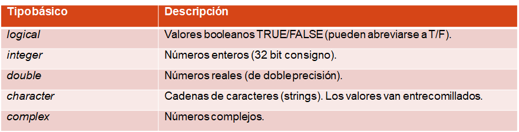

## Objetos comunes en R

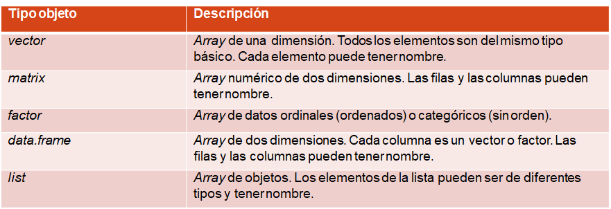

## Naturaleza de los objetos

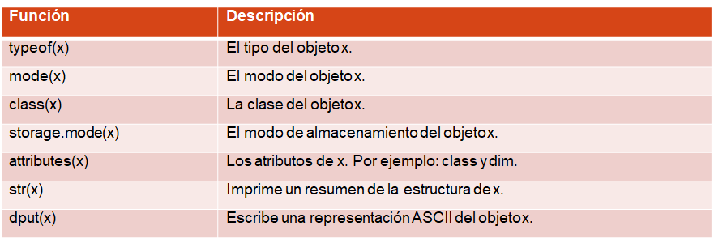

## Valores no numéricos

Existen ciertos valores especiales para representar situaciones determinadas:

- **NULL**: se utiliza para indicar que una variable no contiene ningún objeto.
- **NA**: valor especial para indicar que no hay datos en un determinado lugar (vector, matriz, data frame…)
- **Inf**: infinito positivo.
- **-Inf**: infinito negativo.
- **NaN**: Not a Number.

Tip: se puede tener una lista de NULLs pero no un vector de NULLs. En cambio sí se puede tener un vector de NAs.

```r
a = NA
```

```r
a
```

<NA>

```r
b = NaN
```

```r
b
```

NaN

```r
a == b
```

<NA>

## Operadores Básicos

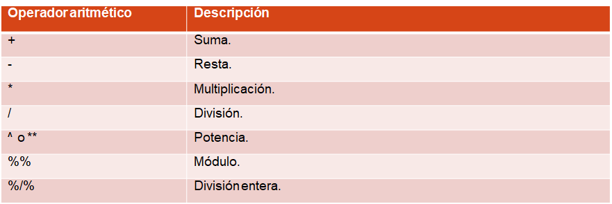

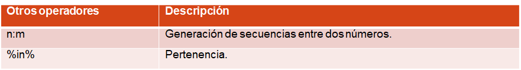

```r
5 %in% c(1, 2, 3, 5)
```

TRUE

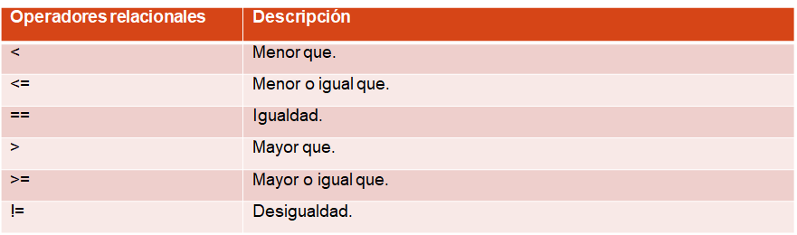

```r
!(TRUE)
```

FALSE

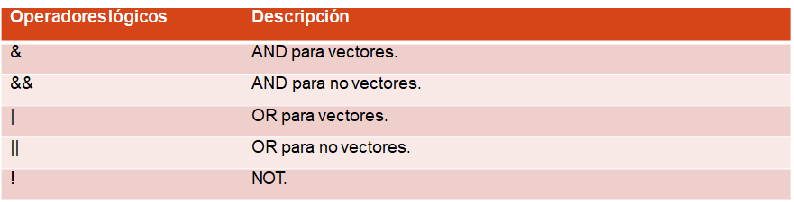

```r
###########################
# Operadores relacionales #
###########################
TRUE == TRUE
```

TRUE

```r
TRUE == FALSE
```

FALSE

```r
"hello" == "goodbye"
```

FALSE

```r
3 == 2
```

FALSE

```r
TRUE != TRUE
```

FALSE

```r
TRUE != FALSE
```

TRUE

```r
"hello" != "goodbye"
```

TRUE

```r
3 != 2
```

TRUE

```r
3 < 5
```

TRUE

```r
3 > 5
```

FALSE

```r
"hello" > "goodbye" # Orden alfabético
```

TRUE

```r
TRUE < FALSE # TRUE coerciona a 1 y FALSE a 0
```

FALSE

```r
5 >= 3
```

TRUE

```r
3 >= 3
```

TRUE

```r
##########################################
# Operadores relacionales sobre vectores #
##########################################
a <- c(16, 9, 13, 5, 2, 17, 14)
a
```

1. 16

2. 9

3. 13

4. 5

5. 2

6. 17

7. 14

```r
a > 10
```

1. TRUE

2. FALSE

3. TRUE

4. FALSE

5. FALSE

6. TRUE

7. TRUE

```r
b <- c(17, 7, 5, 16, 8, 13, 14)
a <= b
```

1. TRUE

2. FALSE

3. FALSE

4. TRUE

5. TRUE

6. FALSE

7. TRUE

```r
######################
# Operadores lógicos #
######################
x <- 12
x > 5 & x < 15
```

TRUE

```r
x <- 17
x > 5 & x < 15
```

FALSE

```r
y <- 4
y < 5 | y > 15
```

TRUE

```r
y <- 14
y < 5 | y > 15
```

FALSE

```r
!(x < 5)
```

TRUE

```r
is.numeric(5)
```

TRUE

```r
!is.numeric(5)
```

FALSE

```r
is.numeric("5")
```

FALSE

```r
!is.numeric("5")
```

TRUE

```r
#####################################
# Operadores lógicos sobre vectores #
#####################################
c(TRUE, TRUE, FALSE) & c(TRUE, FALSE, FALSE)
```

1. TRUE

2. FALSE

3. FALSE

```r
c(TRUE, FALSE, TRUE) && c(TRUE, FALSE, FALSE)
```

TRUE

```r
c(TRUE, TRUE, FALSE) | c(TRUE, FALSE, FALSE)
```

1. TRUE

2. TRUE

3. FALSE

```r
c(TRUE, TRUE, FALSE) || c(TRUE, FALSE, FALSE)
```

TRUE

## Sentencias Condicionales

```r
############################
# Sentencias condicionales #
############################
x <- -3
if (x < 0) {
  print("x es un número negativo")
}
```

```
[1] "x es un número negativo"
```

```r
x <- 5
if (x < 0) {
  print("x es un número negativo")
} else {
  print("x es un número postivo o cero")
}
```

```
[1] "x es un número postivo o cero"
```

```r
x <- 5
if (x < 0) {
  print("x es un número negativo")
} else if (x == 0) {
  print("x es cero")
} else {
  print("x es un número postivo o cero")
}
```

```
[1] "x es un número postivo o cero"
```

```r
ifelse(x > 0, "x es número positivo", "x es un número negativo")
```

'x es número positivo'

```r
x <- "red"

switch(x, red = "cloth", size = 5, name = "table")
```

'cloth'

```r
?switch
```

## Bucles

```r
##########
# Bucles #
##########
ctr <- 1
while (ctr <= 7) {
  print(paste("ctr vale", ctr))
  ctr <- ctr + 1
}
```

```
[1] "ctr vale 1"
[1] "ctr vale 2"
[1] "ctr vale 3"
[1] "ctr vale 4"
[1] "ctr vale 5"
[1] "ctr vale 6"
[1] "ctr vale 7"
```

```r
ctr <- 1
while (ctr <= 7) {
  if (ctr %% 5 == 0)
    break
  print(paste("ctr vale", ctr))
  ctr <- ctr + 1
}
```

```
[1] "ctr vale 1"
[1] "ctr vale 2"
[1] "ctr vale 3"
[1] "ctr vale 4"
```

```r
cities <- c("New York", "Paris", "London", "Tokyo", "Rio de Janeiro", "Cape Town")
for (city in cities) {
  print(city)
}
```

```
[1] "New York"
[1] "Paris"
[1] "London"
[1] "Tokyo"
[1] "Rio de Janeiro"
[1] "Cape Town"
```

```r
cities <- c("New York", "Paris", "London", "Tokyo", "Rio de Janeiro", "Cape Town")
for (city in cities) {
  if (nchar(city) == 6)
    next
  print(city)
}
```

```
[1] "New York"
[1] "Paris"
[1] "Tokyo"
[1] "Rio de Janeiro"
[1] "Cape Town"
```

```r
cities <- c("New York", "Paris", "London", "Tokyo", "Rio de Janeiro", "Cape Town")
for (i in 1:length(cities)) {
  print(paste(cities[i], "está en la posición", i, "del vector de ciudades."))
}
```

```
[1] "New York está en la posición 1 del vector de ciudades."
[1] "Paris está en la posición 2 del vector de ciudades."
[1] "London está en la posición 3 del vector de ciudades."
[1] "Tokyo está en la posición 4 del vector de ciudades."
[1] "Rio de Janeiro está en la posición 5 del vector de ciudades."
[1] "Cape Town está en la posición 6 del vector de ciudades."
```

## Control de Errores

```r
######################
# Control de errores #
######################
inputs = list(1, 2, 4, -5, "oops", 0, 10)

for(input in inputs) {
  print(paste("log of", input, "=", log(input)))
}
```

```
[1] "log of 1 = 0"
[1] "log of 2 = 0.693147180559945"
[1] "log of 4 = 1.38629436111989"
```

```
[1] "log of -5 = NaN"
```

```
Error in log(input): non-numeric argument to mathematical function
Traceback:

1. print(paste("log of", input, "=", log(input)))
2. paste("log of", input, "=", log(input))
```

```r
for(input in inputs) {
  try(print(paste("log of", input, "=", log(input))))
}
```

```
[1] "log of 1 = 0"
[1] "log of 2 = 0.693147180559945"
[1] "log of 4 = 1.38629436111989"
```

```
[1] "log of -5 = NaN"
[1] "log of 0 = -Inf"
[1] "log of 10 = 2.30258509299405"
```

```r
inputs
```

1. 1

2. 2

3. 4

4. -5

5. 'oops'

6. 0

7. 10

```r
inputs
```

1. 1

2. 2

3. 4

4. -5

5. 'oops'

6. 0

7. 10

```r
for(input in inputs) {
  tryCatch(print(paste("log of", input, "=", log(input))),
           warning = function(w) { print(paste("negative argument", log(-input))) },
           error = function(e) { print(paste("non-numeric argument", NaN))})
}
```

```
[1] "log of 1 = 0"
[1] "log of 2 = 0.693147180559945"
[1] "log of 4 = 1.38629436111989"
[1] "negative argument 1.6094379124341"
[1] "non-numeric argument NaN"
[1] "log of 0 = -Inf"
[1] "log of 10 = 2.30258509299405"
```

```r
?tryCatch
```

## Constantes Built-In

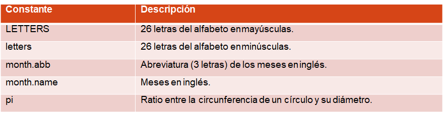

```r
#######################
# Constantes built-in #
#######################
LETTERS
```

1. 'A'

2. 'B'

3. 'C'

4. 'D'

5. 'E'

6. 'F'

7. 'G'

8. 'H'

9. 'I'

10. 'J'

11. 'K'

12. 'L'

13. 'M'

14. 'N'

15. 'O'

16. 'P'

17. 'Q'

18. 'R'

19. 'S'

20. 'T'

21. 'U'

22. 'V'

23. 'W'

24. 'X'

25. 'Y'

26. 'Z'

```r
typeof(LETTERS)
```

'character'

```r
letters
```

1. 'a'

2. 'b'

3. 'c'

4. 'd'

5. 'e'

6. 'f'

7. 'g'

8. 'h'

9. 'i'

10. 'j'

11. 'k'

12. 'l'

13. 'm'

14. 'n'

15. 'o'

16. 'p'

17. 'q'

18. 'r'

19. 's'

20. 't'

21. 'u'

22. 'v'

23. 'w'

24. 'x'

25. 'y'

26. 'z'

```r
month.abb
```

1. 'Jan'

2. 'Feb'

3. 'Mar'

4. 'Apr'

5. 'May'

6. 'Jun'

7. 'Jul'

8. 'Aug'

9. 'Sep'

10. 'Oct'

11. 'Nov'

12. 'Dec'

```r
month.name
```

1. 'January'

2. 'February'

3. 'March'

4. 'April'

5. 'May'

6. 'June'

7. 'July'

8. 'August'

9. 'September'

10. 'October'

11. 'November'

12. 'December'

```r
pi
```

3.14159265358979

```r
a <- c(1, 2, 3)
```

```r
b <- 'A'
```

```r
c <- c(a, b)
```

```r
c
```

1. '1'

2. '2'

3. '3'

4. 'A'

## Inspección de objetos

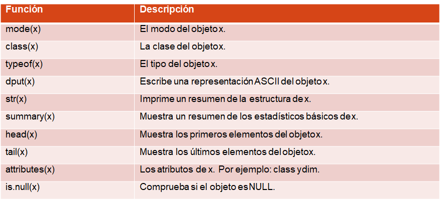

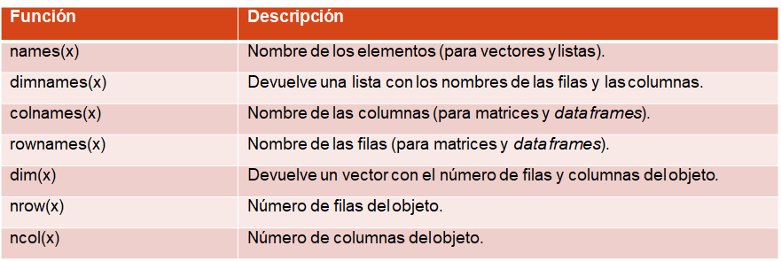

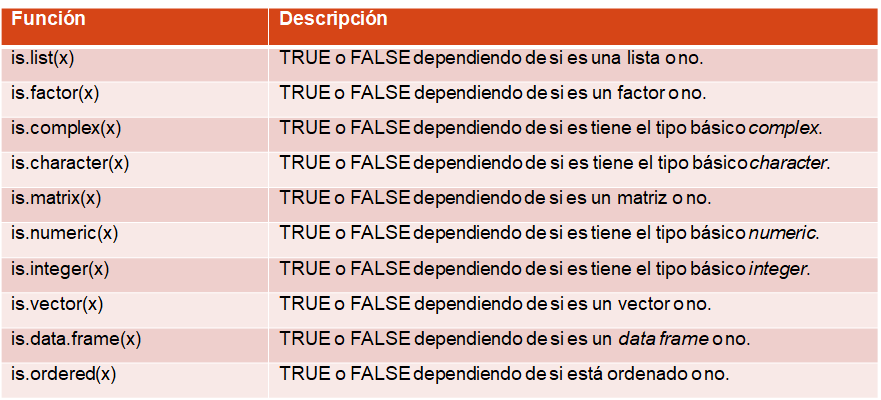

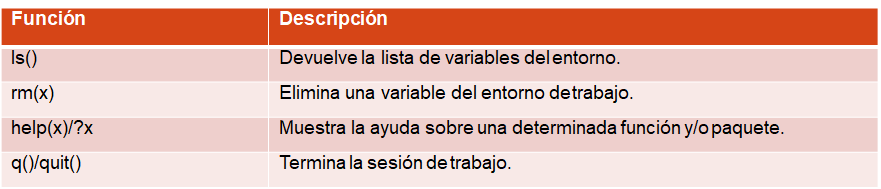

## Ejercicio

```r
###################################
# Basics: operadores aritméticos  #
###################################

# Suma 5 + 5
5+5
```

10

```r
# Resta 5 - 5
5 - 5
```

0

```r
# Multiplica 3 * 5
3 * 5
```

15

```r
# Suma 5 +5 y divide el resultado entre 2
(5 + 5 ) / 2
```

5

```r
# Calcula 2 elevado a 5
2^5
```

32

```r
# Calcula modulo de 28 entre 6
28 %% 6
```

4

```r
###################################
# Basics: asignación de variables #
###################################

# Asgina el valor 5 a la variable my_apples
my_apples <- 5
```

```r
# Muestra el contenido de la variable my_apples
my_apples
```

5

```r
# Asgina el valor 6 a la variable my_pears
my_pears = 6
```

```r
# Muestra el contenido de la variable my_pears
my_pears
```

6

```r
# Suma peras con manzanas: crea una nueva variable my_fruit con la suma
my_fruit = my_apples + my_pears
```

```r
# Muestra el número total de piezas de fruta
my_fruit
```

11

```r
###################################
# Basics: tipos básicos           #
###################################

# Declara una variable numérica, my_numeric, con el valor 42
my_numeric = 42
```

```r
# Declara una variable de tipo texto, my_character, con el valor "forty-two"
my_character = "forty_two"
```

```r
# Declara una variable booleana, my_logical, con el valor FALSE
my_logical = FALSE
```

```r
# ¿De qué tipo son?
typeof(my_numeric)
typeof(my_character)
typeof(my_logical)
```

'double'

'character'

'logical'

```r
# ¿De qué clase son?
class(my_numeric)
class(my_character)
class(my_logical)
```

'numeric'

'character'

'logical'

```r
# ¿Cuál es su modo?
mode(my_numeric)
mode(my_character)
mode(my_logical)
```

'numeric'

'character'

'logical'

```r
rm(d)
```

```r
d
```

```
Error in eval(expr, envir, enclos): objeto 'd' no encontrado
Traceback:
```

```r
my_func <- function(){d <<- -5}
```

```r
my_func()
```

```r
d
```

-5